# Анализ мощности, часть 2

## Математические методы в зоологии - на R, осень 2013

Марина Варфоломеева  
Каф. Зоологии беспозвоночных, СПбГУ

# Экономим силы с помощью анализа мощности

- *A priori* анализ мощности
- Оценка величины эффекта
- *Post hoc* анализ мощности

# Вы сможете

- оценивать величину эффекта и необходимый объем выборки по данным пилотного исследования
- загружать данные из .xls в R
- строить гистограммы и боксплоты с помощью `ggplot2`
- сравнивать средние значения при помощи t-критерия, интерпретировать и описывать результаты
- расчитывать фактическую мощность теста

# На чем мы остановились?

# Пример: Улитки на устрицах в мангровых зарослях *

В каких зонах мангровых зарослей на устрицах предпочитают обитать улитки?

Minchinton, Ross, 1999

- Зона зарослей - 4 (по 5 проб - число улиток на раковинах устриц)
  - LZ - ближе к земле,
  - MZ - средняя часть, с деревьями,
  - SZ(-TR) - ближе к морю, с деревьями
  - SZ(+TR) - ближе к морю, без деревьев
- Сайт - 2
  - A
  - B

* - Данные из Quinn, Keough, 2002, Box 9-5, Fig 9-7

# Читаем данные из файла

Не забудте войти в вашу директорию для матметодов, например, так

```r
# setwd("C:\\Мои\ документы\\mathmethR\\) # в Windows
# setwd(/home/yourusername/mathmethR/) # в Linux

library(XLConnect)
wb <- loadWorkbook("./data/minch.xls")
minch <- readWorksheet(wb, sheet = 1)
```

# Какой формы распределение численности улиток для двух сайтов?

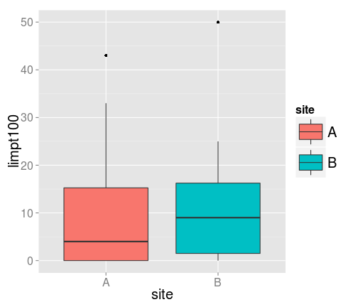

```r
library(ggplot2)
bp <- ggplot(data = minch, aes(x = site, y = limpt100, fill = site)) +
  geom_boxplot()
bp
```

# А если взять квадратный корень из численности?

Стало ли распределение больше походить на нормальное?

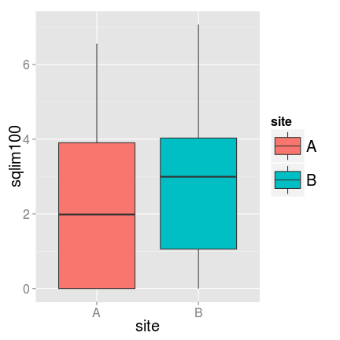

```r
bp + aes(y = sqlim100)
```

# A priory анализ мощности по данным пилотного исследования

# Представим, что было пилотное исследование:

2 сайта, 4 зоны, по 2 пробы

```r
wb1 <- loadWorkbook("./data/minch_smpl.xls")
minch_smpl <- readWorksheet(wb1, sheet = 1)
```

# Мы хотим сравнить сайты

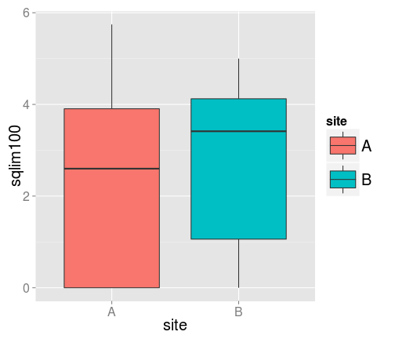

```r
ggplot(data = minch_smpl, aes(x = site, y = sqlim100)) +
  geom_boxplot(aes(fill = site))
```

# Величина эффекта по исходным данным

```r
library(effsize)
effect <- cohen.d(minch_smpl$sqlim100, minch_smpl$site)
effect
```

```
##
## Cohen's d
##
## d estimate: -0.159 (negligible)
## 95 percent confidence interval:
##     A     A
## -1.31  0.99
```

- дальше нам понадобится строка "d estimate: -0.159 (negligible)"  
  как добыть из нее значение?

# Как называется в структуре объекта элемент, где записана величина эффекта?

```r
str(effect)
```

```
## List of 7
##  $ method    : chr "Cohen's d"
##  $ name      : chr "d"
##  $ estimate  : Named num -0.159
##   ..- attr(*, "names")= chr "A"
##  $ conf.int  : Named num [1:2] -1.31 0.99
##   ..- attr(*, "names")= chr [1:2] "A" "A"
##  $ var       : Named num 0.535
##   ..- attr(*, "names")= chr "A"
##  $ conf.level: num 0.95
##  $ magnitude : chr "negligible"
##  - attr(*, "class")= chr "effsize"
```

# Чтобы добыть величину эффекта, назовем его по имени с помощью оператора $

`$` - для обращения к переменным по именам (для обращения к элементам сложного объекта)

```r
str(effect)
```

```
## List of 7
##  $ method    : chr "Cohen's d"
##  $ name      : chr "d"
##  $ estimate  : Named num -0.159
##   ..- attr(*, "names")= chr "A"
##  $ conf.int  : Named num [1:2] -1.31 0.99
##   ..- attr(*, "names")= chr [1:2] "A" "A"
##  $ var       : Named num 0.535
##   ..- attr(*, "names")= chr "A"
##  $ conf.level: num 0.95
##  $ magnitude : chr "negligible"
##  - attr(*, "class")= chr "effsize"
```

```r
effect$estimate
```

```
##      A
## -0.159
```

# Для pwr.t.test() эффект должен быть положительным

```r
effect <- abs(effect$estimate) # абсолютная величина (модуль)
effect
```

```
##     A
## 0.159
```

- Очень слабый эффект...

# Post hoc анализ мощности

# Что получилось бы на самом деле?

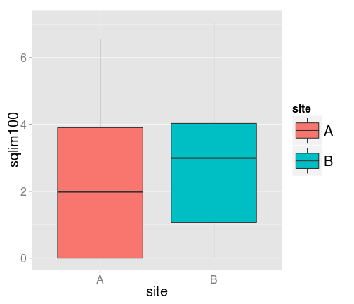

```r
# bp <- ggplot(data = minch, aes(x = site, y = limpt100)) + geom_boxplot()
bp + aes(y = sqlim100)
```

# Считаем t-критерий

по умолчанию Модификация Велча - для неравных дисперсий

```r
t.test(sqlim100 ~ site, data = minch, var.equal = FALSE)
```

```
##
##  Welch Two Sample t-test
##
## data:  sqlim100 by site
## t = -1.15, df = 38, p-value = 0.2556
## alternative hypothesis: true difference in means is not equal to 0
## 95 percent confidence interval:
##  -2.198  0.602
## sample estimates:
## mean in group A mean in group B
##            2.11            2.91
```

# Для post hoc анализа нужно знать

# Пример: Улитки на устрицах в мангровых зарослях *

Какова была реальная величина эффекта?

Хватило ли нам мощности, чтобы выявлять такие незначительные различия?

* - Данные из Quinn, Keough, 2002, Box 7-1, Fig 7-4

# Что мы знаем для post hoc анализа?

- тест
- уровень значимости
- фактический объем выборки
- фактическая величина эффекта

# Что мы знаем для post hoc анализа?

- тест — t-критерий
- уровень значимости — α = 0.05
- фактический объем выборки — 20
- фактическая величина эффекта — ?

# Минимальные выявляемые различия

$$d={{|\bar x _1 - \bar x _2 |} \over {\sqrt{{s_1^2 + s_2^2 } \over {2} }}}$$

$$MDES = {|\bar x _1 - \bar x _2 |} = d {\sqrt{{s_1^2 + s_2^2 } \over {2} }}$$

# Найдем Коэновскую величину эффекта

```r
d <- pwr.t.test(n = 20, d = NULL, power = 0.8, sig.level = 0.05,
                type = "two.sample", alternative = "two.sided")
str(d)
```

```
## List of 7
##  $ n          : num 20
##  $ d          : num 0.909
##  $ sig.level  : num 0.05
##  $ power      : num 0.8
##  $ alternative: chr "two.sided"
##  $ note       : chr "n is number in *each* group"
##  $ method     : chr "Two-sample t test power calculation"
##  - attr(*, "class")= chr "power.htest"
```

```r
d$d
```

```
## [1] 0.909
```

# Минимальные выявляемые различия

$$MDES = d {\sqrt{{s_1^2 + s_2^2 } \over {2} }}$$

```r
library(plyr) # пакет, чтобы делать статистику по группам
(summary_by_site <- ddply(minch, ~ site, summarize,
                         mean = mean(sqlim100),
                         var = var(sqlim100)))
```

```
##   site mean  var
## 1    A 2.11 4.84
## 2    B 2.91 4.73
```

```r
(MDES <- d$d * sqrt(sum(summary_by_site$var)/2))
```

```
## [1] 1.99
```

```r
(diff <- summary_by_site$mean[2] - summary_by_site$mean[1])
```

```
## [1] 0.798
```

# Мощность при разных объемах групп

# А что если бы было не по 20 проб на каждом сайте?

Улитки на устрицах в мангровых зарослях

- сайт A - 20 проб
- сайт B - 40 проб

```r
pwr.t2n.test()
```

# Мощность при разных объемах групп

```r
# effect_real <- cohen.d(minch$sqlim100, minch$site)
# effect_real <- abs(effect_real$estimate)
pwr.t2n.test(n1 = 20, n2 = 40, d = effect_real, power = NULL,
             sig.level = .05, alternative = "two.sided")
```

```
##
##      t test power calculation
##
##              n1 = 20
##              n2 = 40
##               d = 0.365
##       sig.level = 0.05
##           power = 0.259
##     alternative = two.sided
```

- Все равно мощность маленькая! Важен ли такой эффект? Стоит ли за ним гоняться?

# Как влиять на мощность теста?

# Мощность зависит

- от объема выборки
- от величины эффекта
- от уровня значимости

# Чем больше объем выборки—тем больше мощность

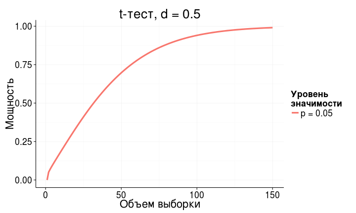

# Чем больше уровень значимости—тем больше мощность

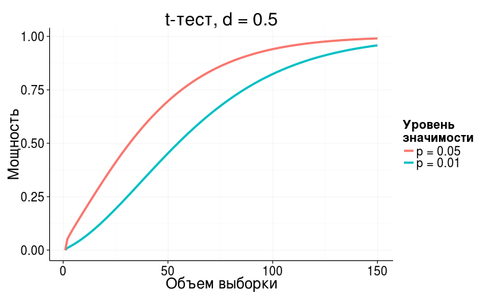

# Чем больше величина различий—тем больше мощность

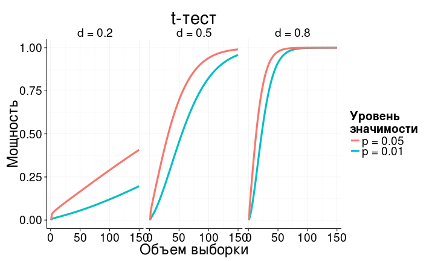

# Мы не можем контролировать внешние факторы

- величину эффекта ($ES$)
- фоновую изменчивость ($\sigma^2$)

# Мощность теста можно регулировать, если

- изменить число повторностей
- выбрать другой уровень значимости ($\alpha$)
- определиться, какие эффекты действительно важны ($ES$)

# Take home messages

- Контролируем статистические ошибки:
  - чтобы не находить несуществующих эффектов, фиксируем уровень значимости
  - чтобы не пропустить значимое, рассчитываем величину эффекта, объем выборки и мощность теста
  - когда не обнаружили достоверных эффектов, оцениваем величину эффекта и мощность теста
- Способность выявлять различия зависит
  - от объема выборки,
  - от уровня значимости
  - от величины эффекта

# Дополнительные ресурсы

- Quinn, Keough, 2002, pp. 164-170
- Open Intro to Statistics: [4.6 Sample Size and Power](http://www.openintro.org/stat/down/oiStat2_04.pdf), pp. 193-197
- Sokal, Rohlf, 1995, pp. 167-169.
- Zar, 1999, p. 83.
- [R Data Analysis Examples - Power Analysis for Two-group Independent sample t-test. UCLA: Statistical Consulting Group.](http://www.ats.ucla.edu/stat/r/dae/t_test_power2.htm)
- [R Data Analysis Examples - Power Analysis for One-sample t-test. UCLA: Statistical Consulting Group.](http://www.ats.ucla.edu/stat/r/dae/t_test_power.htm)
- [FAQ - How is effect size used in power analysis? UCLA: Statistical Consulting Group.](http://www.ats.ucla.edu/stat/mult_pkg/faq/general/effect_size_power/effect_size_power.htm)